# p8130_hw1_ym2813

Anna Ma

9/26/2021

# Problem 1

## Please classify each of the following variables as qualitative (specify if binary, nominal, or ordinal) or quantitative (specify if discrete or continuous):

### a)homework feedback, labeled as “poor”, “fair”, “good”, “very good”

This is an ordinal qualitative variable.

### b)homework feedback, labeled as “fail”, “pass”

This is a binary qualitative variable.

### c)country of birth

This is a nominal qualitative variable.

### d)the quantity of grapes (in lbs)to make 3 liters of wine

This is a continuous quantitative variable.

### e)number of TAs in the P8130 course

This is a discrete quantitative variable.

# Problem 2

## In a study of 133 individualswith a recent bike crash history,depression scores were measured using a standardized test.The depression scores for 14 of these individualsare as follows: 45, 39, 25, 47, 49, 5, 70, 99, 74, 37, 99, 35, 8, 59

### a) Computethe following descriptive summariesof these data: mean, median, range, SD.

```r
depression_score_2.1 <- c(45, 39, 25, 47, 49, 5, 70, 99, 74, 37, 99, 35, 8, 59)
mean(depression_score_2.1) # Data mean
```

```
## [1] 49.35714
```

```r
median(depression_score_2.1)  # Data median
```

```
## [1] 46
```

```r
max(depression_score_2.1, na.rm = TRUE) - min(depression_score_2.1, na.rm = TRUE)   # Data range
```

```
## [1] 94
```

```r
sd(depression_score_2.1)  #Data standrd deviation
```

```
## [1] 28.84603
```

The mean of the depression scores for the 14 individuals is 49.3571429, the median of is 46, the range is 94, and the standard deviation is 28.8460293

### b) Describe the box plot and the underlying distribution of the data. Use some of the following terms:left-skewed, right-skewed, symmetric, bimodal, unimodal distribution.

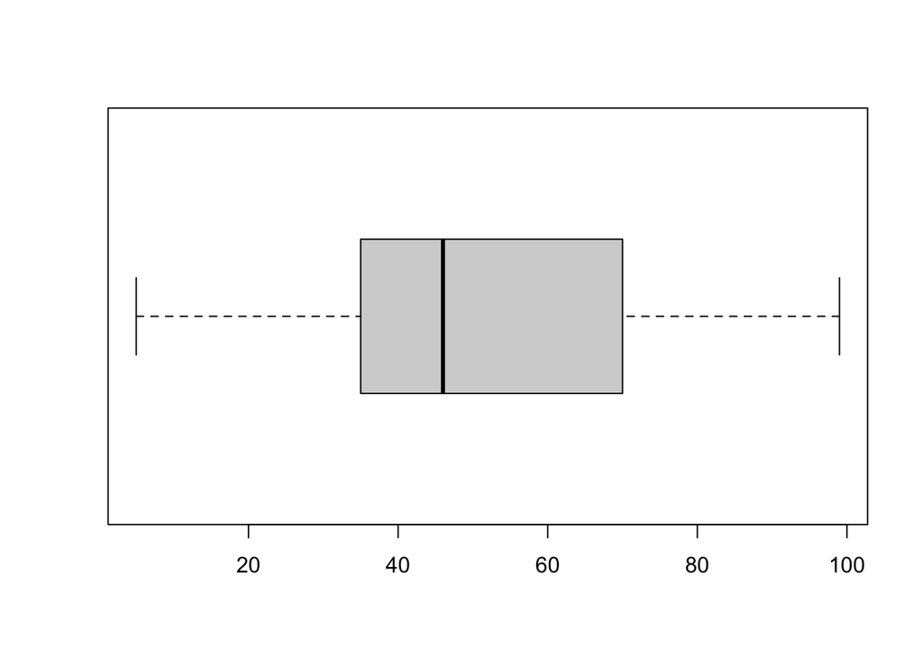

```r
boxplot(depression_score_2.1,horizontal = TRUE)
```

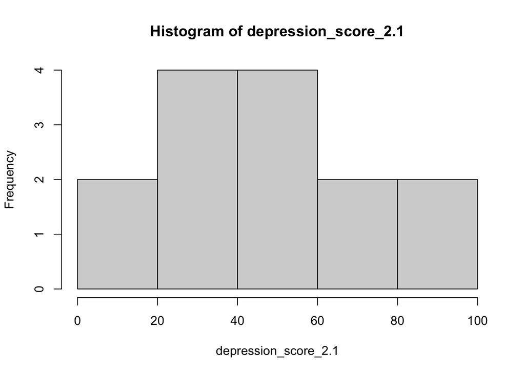

```r
hist(depression_score_2.1)
```

## Additionally, 140 individuals with a recent car crash history alsoparticipated in the study.The depression scores for 13 of these individualsare given below: 67, 50, 85, 43, 64, 35, 47, 97, 58, 58, 10, 56, 50

### a) Using R, make a side-by-side box plot of the depression scores stratified by type of accident.Make sure you label your figure appropriately.

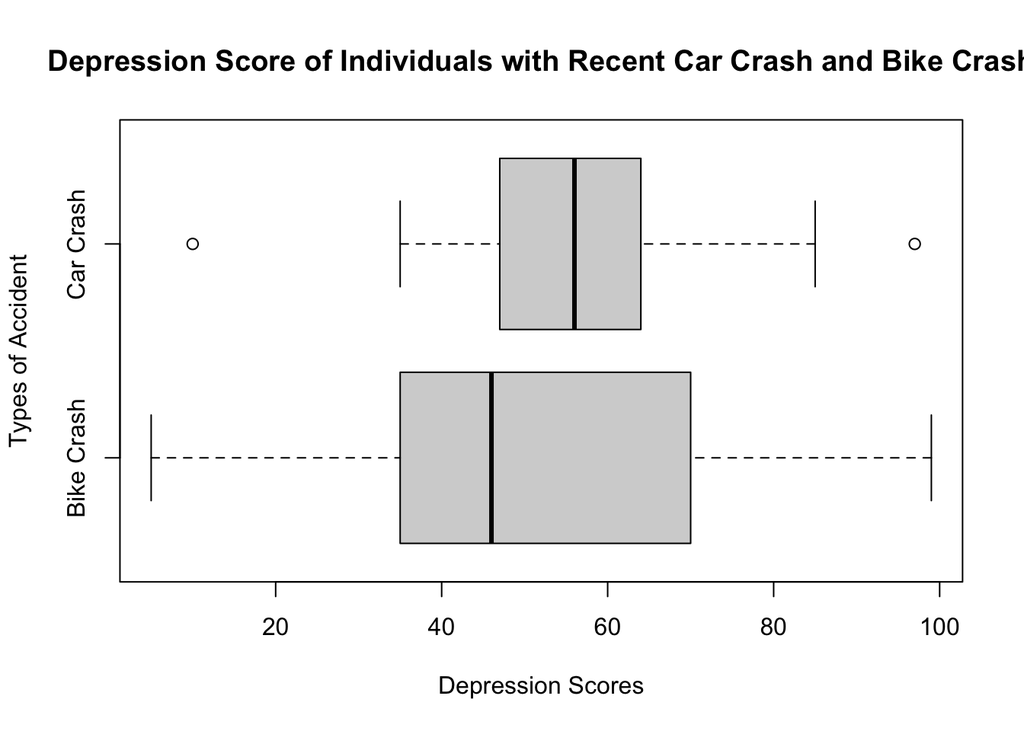

```r
depression_score_2.2 <- c(67, 50, 85, 43, 64, 35, 47, 97, 58, 58, 10, 56, 50)
types <- c("Bike Crash","Car Crash")
boxplot(depression_score_2.1,
        depression_score_2.2,
        names = types, horizontal = TRUE,
        main = "Depression Score of Individuals with Recent Car Crash and Bike Crash",
        xlab = "Depression Scores",
        ylab = "Types of Accident")
```

### b) Describe each of the box plots and the underlying distribution of the data. Use some of the following terms:left-skewed, right-skewed, symmetric, bimodal, unimodal distribution.

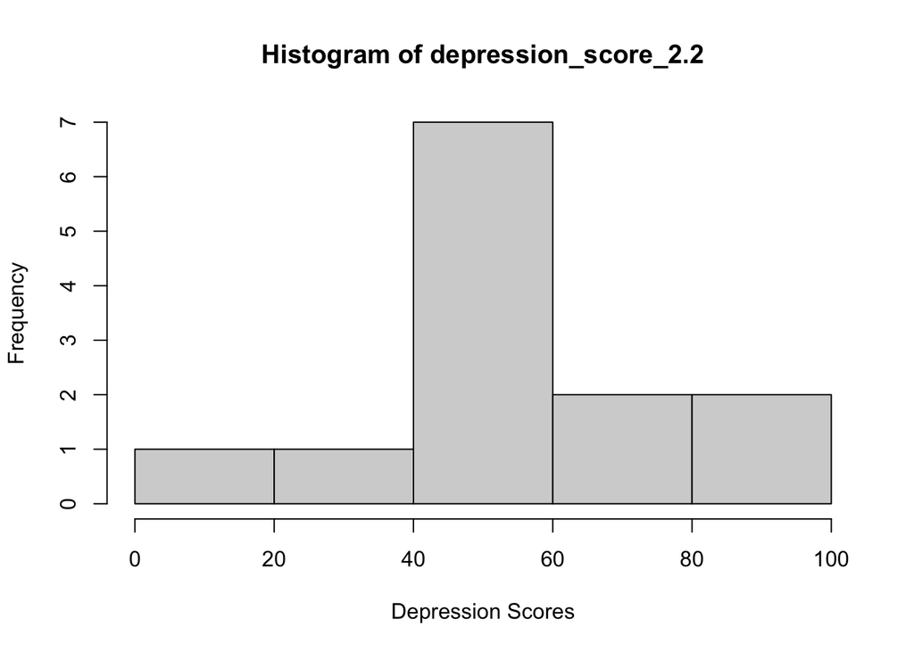

```r
hist(depression_score_2.2,xlab = "Depression Scores")
```

### c) Comparing the 2 box plots,which group appears to have a lower typical depression score?

It appears that the group who had bike crash have a lower typical depression score.

# Problem 3

## Suppose we toss one fair 12-sided die:

### a)Let’s define the event A as “an even number appears”. What is the probability of the event A?

The probability of even A is
$$P=\frac{A}{All~Possible~Numbers}=\frac{6}{12}=\frac{1}{2}$$

### b)Let’s define the event B as “number 10 appears”. What is the probability of the event B?

The probability of even A is
$$P=\frac{B}{All~Possible~Numbers}=\frac{1}{12}$$

### c)Compute P(B U A).

$$P(B\cup A)=P(A) + P(B)-P(B\cap A)=\frac{1}{2}+\frac{1}{12}-\frac{1}{12}=\frac{1}{2}$$

### d) Are events A and B independent? Why?Prove your answer.

Event A and B is not independent:

$proof:$ By definition, A and B are independent events if and only if P(A|B) = P(A). Given that B has already occurred such that number 10 has appeared, then the probability of an even number appears, which is event A, should be 1. However, P(A) is $\frac{1}{2}$ as shown in a). Therefore,P(A|B) is not equal to P(A). Thus, A and B are not independent. $\square$